#### TASK #1.1 Measures of Center

- Write your own function or one-liner to calculate mean, median, mode
- Check the correctness using built-in functions for mean and median (there is no function for mode - try your one for different cases)
- Visualize (histogram or density plot) the result for all these measures
- Spoil you data with an outlier and repeat previous step

```r
v <- c(175, 176, 182, 165, 167, 172, 175, 196, 158, 172)
v_sp <- c(v, 0)
```

```r
plot_hist <- function(x, x_sp, title, fun) {
  original <- data.frame(height = x, group = "original")
  spoiled <- data.frame(height = x_sp, group = "spoiled")
  dataviz <- rbind(original, spoiled)

  x_fun <- fun(x)
  x_sp_fun <- fun(x_sp)

  vline <- data.frame(z = c(x_fun, x_sp_fun), group = c("original", "spoiled"))
  ggplot(dataviz, aes(x = height)) +
      geom_histogram(binwidth = 5) +
      geom_vline(aes(xintercept = z), vline, colour = "red")+
      facet_grid(group ~ .) +
      theme_bw() + ggtitle(title)
}
```

## Mean

```r
my_mean <- function(x){
  sum(x) / length(x)
}

# v_mean <- my_mean(v)
# v_mean_sp <- my_mean(v_sp)

if (my_mean(v) == mean(v)) "Mean is correct! my_mean(v) = mean(v)"
```

```
## [1] "Mean is correct! my_mean(v) = mean(v)"
```

```r
if (my_mean(v_sp) == mean(v_sp)) "Mean is correct! my_mean(v_sp) = mean(v_sp)"
```

```
## [1] "Mean is correct! my_mean(v_sp) = mean(v_sp)"
```

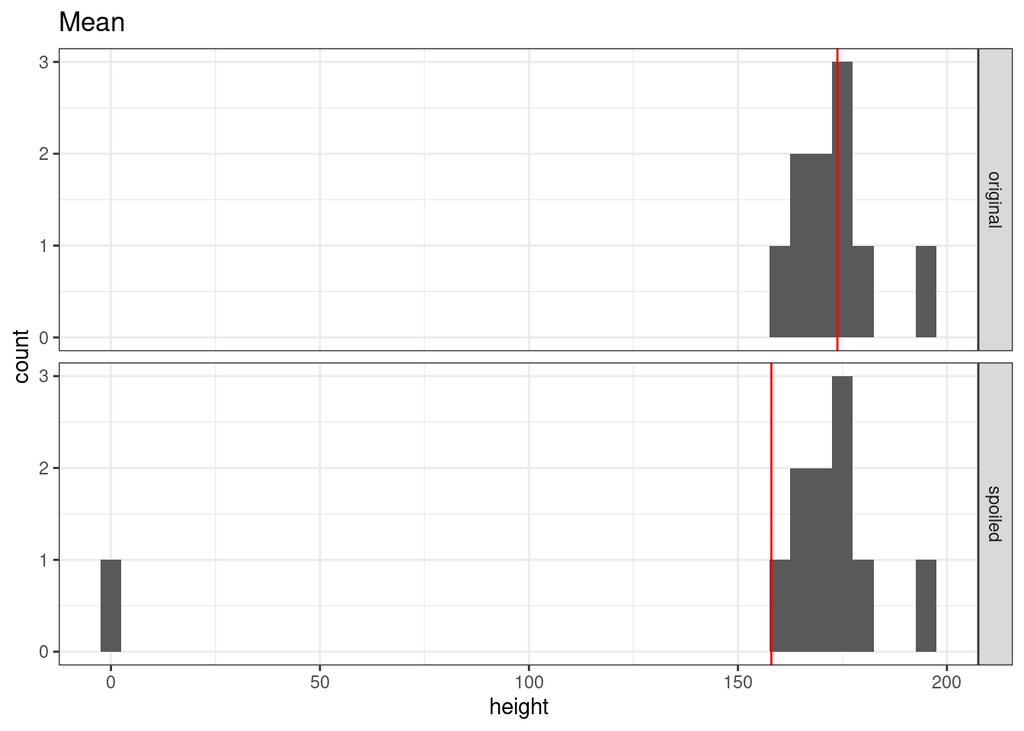

```r
plot_hist(v, v_sp, "Mean", my_mean)
```

## Median

```r
my_median <- function(x){
  n = length(x)
  half <- n %/% 2

  if(n %% 2 == 1) sort(x)[half]
  else mean(sort(x)[half:(half+1)])
}

# v_median <- my_median(v)
# v_median_sp <- my_median(v_sp)

if (my_median(v) == median(v)) "Median is correct! my_median(v) = median(v)"
```

```
## [1] "Median is correct! my_median(v) = median(v)"
```

```r
if (my_median(v_sp) == median(v_sp)) "Median is correct! my_median(v_sp) = median(v_sp)"
```

```
## [1] "Median is correct! my_median(v_sp) = median(v_sp)"
```

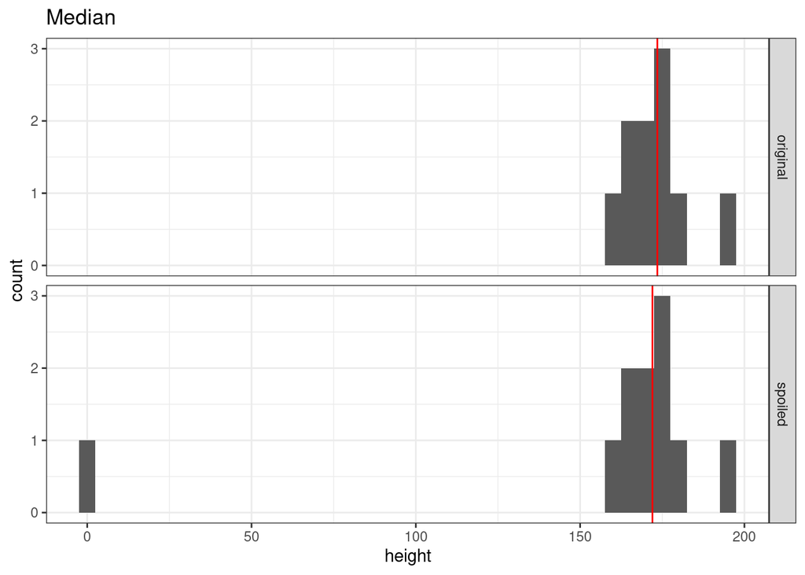

```r
plot_hist(v, v_sp, "Median", my_median)
```

## Mode

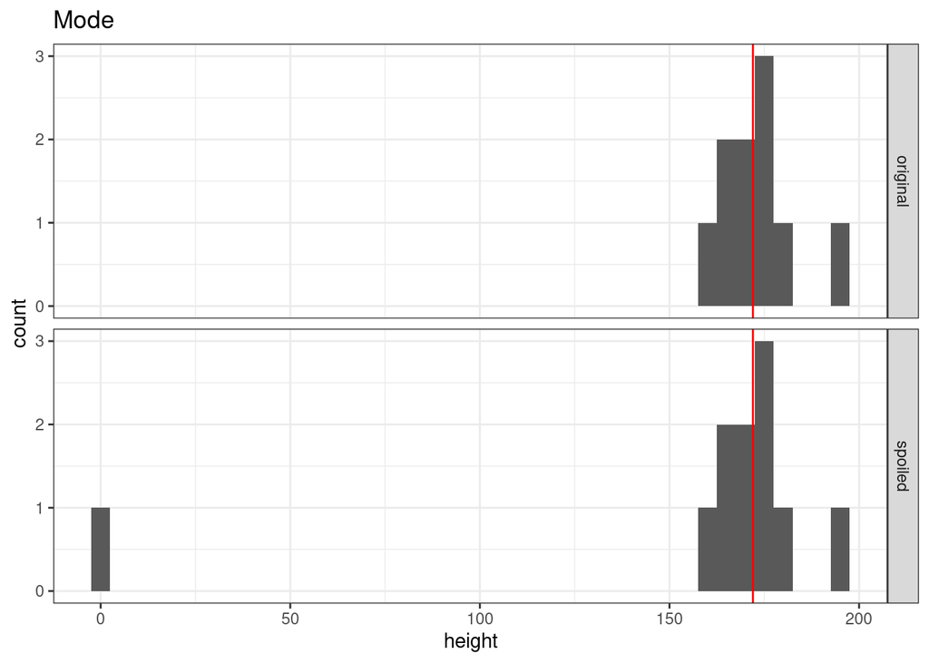

```r
my_mode <- function(x) {
  strtoi(names(sort(table(x), decreasing = TRUE)[1]), base=0L)
}

# v_mode <- my_mode(v)
# v_mode_sp <- my_mode(v_sp)

plot_hist(v, v_sp, "Mode", my_mode)
```

#### TASK #1.2 Measures of Spread

- Write your own function or one-liner to calculate variance and sd
- Check the correctness using built-in functions
- Visualize (boxplot) the result for: Q1+Q3, 1-sd borders
- Spoil you data with an outlier and repeat previous step

```r
v_rpl <- replace(v, 1, 0)
```

## Variance

```r
my_var <- function(x) {
  sum((x - mean(x))^2) / (length(x) - 1)
}

if (my_var(v) == var(v)) "Variance is correct! my_var(v) = var(v)"
```

```
## [1] "Variance is correct! my_var(v) = var(v)"
```

```r
if (my_var(v_rpl) == var(v_rpl)) "Variance is correct! my_var(v_rpl) = var(v_rpl)"
```

```
## [1] "Variance is correct! my_var(v_rpl) = var(v_rpl)"
```

## SD

```r
my_sd <- function(x) {
  sqrt(my_var(x))
}

if (my_sd(v) == sd(v)) "SD is correct! my_sd(v) = sd(v)"
```

```
## [1] "SD is correct! my_sd(v) = sd(v)"
```

```r
if (my_sd(v_rpl) == sd(v_rpl)) "SD is correct! my_sd(v_rpl) = sd(v_rpl)"
```

```
## [1] "SD is correct! my_sd(v_rpl) = sd(v_rpl)"
```

#### TASK #1.3 Properties of Measures

- Check the properties for your sample
- Visualize result tabularly (for # 1-6) and graphically (for # 2 and 6)

```r
Name <- c("mean(v - 100) == mean(v) - 100",
          "mean(v / 100) == mean(v) / 100",
          "sum(v - mean(v))",
          "var(v - 100) == var(v)",
          "var(v / 100) == var(v) / 10000",
          "sd(v / 100) == sd(v) / 100")
Value <- c(
  round(my_mean(v - 100), 6) == round(my_mean(v) - 100, 6), # 1
  round(my_mean(v / 100), 6) == round(my_mean(v) / 100, 6), # 2
  round(sum(v - my_mean(v)), 6), # 3
  round(my_var(v - 100), 6) == round(my_var(v), 6), # 4
  round(my_var(v / 100), 6) == round(my_var(v) / 10000, 6), # 5
  round(my_sd(v / 100), 6) == round(my_sd(v) / 100, 6) # 6
)

properties <- data.frame(Name, Value)
properties
```

```
##                             Name Value
## 1 mean(v - 100) == mean(v) - 100     1
## 2 mean(v / 100) == mean(v) / 100     1
## 3               sum(v - mean(v))     0
## 4         var(v - 100) == var(v)     1
## 5 var(v / 100) == var(v) / 10000     1
## 6     sd(v / 100) == sd(v) / 100     1
```

```r
plot_properties <- function(x, denominator, title, fun, fun_name) {
  x_dv <- x / denominator

  original <- data.frame(height = x, group = "original")
  trans_dv <- data.frame(height = x_dv, group = sprintf("x / %d", denominator))
  dataviz <- rbind(original, trans_dv)

  x_fun <- fun(x) / denominator
  x_dv_fun <- fun(x_dv)

  vline <- data.frame(z = c(x_fun, x_dv_fun), group = c("original", sprintf("x / %d", denominator)))

  if (fun_name == 'mean'){
    ggplot(dataviz, aes(x = height)) +
        geom_density() +
        geom_vline(aes(xintercept = z), vline, colour = "red")+
        facet_wrap(vars(group), nrow = 2, scales = 'free_y') +
        theme_bw() + ggtitle(sprintf(title, denominator, denominator))
  }
  else {
    ggplot(dataviz, aes(x = height)) +
        geom_density() +
        geom_vline(aes(xintercept = z), mean(dataviz)-vline, colour = "red")+
        geom_vline(aes(xintercept = z), mean(dataviz)+vline, colour = "red")+
        facet_wrap(vars(group), nrow = 2, scales = 'free_y') +
        theme_bw() + ggtitle(sprintf(title, denominator, denominator))
  }
}
```

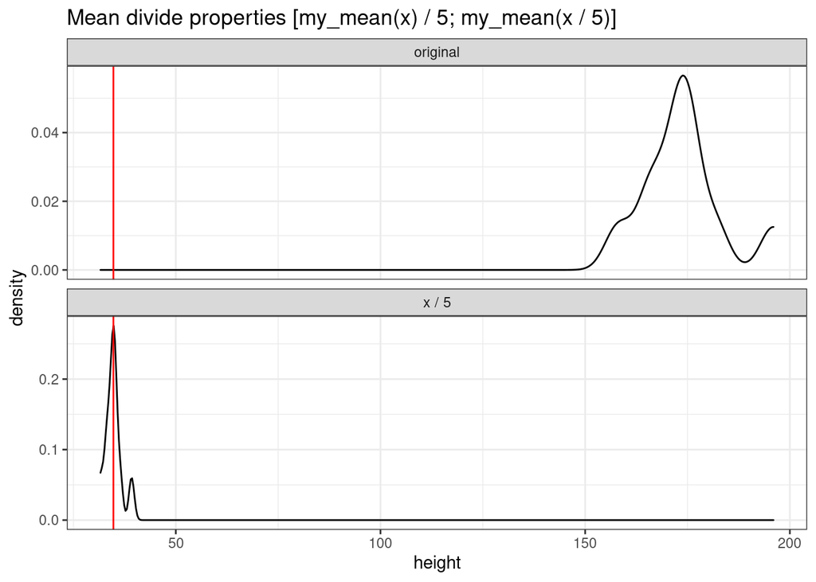

```r
denominator = 5
plot_properties(v, denominator, "Mean divide properties [my_mean(x) / %d; my_mean(x / %d)]", my_mean, 'mean')
```

[figure not shown]

```r
denominator = 5
plot_properties(v, denominator, "Sd divide properties [my_sd(x) / %d; my_sd(x / %d)]", sd, 'sd')
```

### Custom Report

#### TASK #1.4 Statistical Report, part 1

Create descriptive statistics on Pima data set (excluding first and last column) containing information for each column such as: - Number of valid observations (not NA) - Number of missing (NA) values - Mean, Median - Min, max - Q1, Q3 - IQR, SD

Order of columns: - Measure column first, then all the others in free order Order of measures: - As presented below

Values rounded to the 2nd digit

```r
library(dplyr)

data(PimaIndiansDiabetes2)
df <- PimaIndiansDiabetes2[2:8]

my_summary <- function(x) {
  q1 <- round(sapply(x, quantile, probs = 0.25, na.rm = TRUE), 2)
  q3 <- round(sapply(x, quantile, probs = 0.75, na.rm = TRUE), 2)
  res <- data.frame(
    N = sapply(x, function(x) sum(!is.na(x))),
    Missed = sapply(x, function(x) sum(is.na(x))),
    Mean = round(sapply(x, mean, na.rm = TRUE), 2),
    Median = round(sapply(x, median, na.rm = TRUE), 2),
    Min = round(sapply(x, min, na.rm = TRUE), 2),
    Max = round(sapply(x, max, na.rm = TRUE), 2),
    Q1 = q1,
    Q3 = q3,
    IQR = q3 - q1,
    SD = round(sapply(x, sd, na.rm = TRUE), 2)
    )
  res <- t(res)
  data.frame(res[,order(colnames(res))])
}

df <- my_summary(df)
tibble(cbind(Measurements = row.names(df), df))%>%
    knitr::kable()
```

| Measurements | age | glucose | insulin | mass | pedigree | pressure | triceps |
| --- | --- | --- | --- | --- | --- | --- | --- |
| N | 768.00 | 763.00 | 394.00 | 757.00 | 768.00 | 733.00 | 541.00 |
| Missed | 0.00 | 5.00 | 374.00 | 11.00 | 0.00 | 35.00 | 227.00 |
| Mean | 33.24 | 121.69 | 155.55 | 32.46 | 0.47 | 72.41 | 29.15 |
| Median | 29.00 | 117.00 | 125.00 | 32.30 | 0.37 | 72.00 | 29.00 |
| Min | 21.00 | 44.00 | 14.00 | 18.20 | 0.08 | 24.00 | 7.00 |
| Max | 81.00 | 199.00 | 846.00 | 67.10 | 2.42 | 122.00 | 99.00 |
| Q1 | 24.00 | 99.00 | 76.25 | 27.50 | 0.24 | 64.00 | 22.00 |
| Q3 | 41.00 | 141.00 | 190.00 | 36.60 | 0.63 | 80.00 | 36.00 |
| IQR | 17.00 | 42.00 | 113.75 | 9.10 | 0.39 | 16.00 | 14.00 |
| SD | 11.76 | 30.54 | 118.78 | 6.92 | 0.33 | 12.38 | 10.48 |